# Efficient Multivariate Conditional Autoregressive (MCAR) prior in Stan

By James Hogg - 2023

# Introduction

Multivariate conditional autoregressive (MCAR) priors are one way of simultaneously accommodating spatial structure and dependence between several factors [1].

The key result from this analysis is the comparison of the accuracy and speed between the naive and efficient implementations of the proper multivariate CAR prior. The Stan code for the implementations can be found in `vignettes\stan`. Unfortunately given how computationally expensive the MPCAR is, and thus how prohibitively long it takes to sample, we use a very small example to start with. Here we simulate data from the corresponding MCAR distribution using 50 areas and 5 factors.

# Simulate data

Before fitting our efficient Stan implementations in Stan we’ll generate and visualize some multivariate spatial data using a normal likelihood.

```r
# number of areas
M <- 50
# number of factors
K <- 5
# set the spatial smoothing parameter
rho <- 0.90 # common to all factors

# Get weight matrix for fully connected grid
spat_obj <- getGRID(M)
W <- spat_obj$W
M <- nrow(W)

# dimension of multivariate normal
n <- M*K

## Spatial precision matrix ----
I <- diag(x=1, nrow = M)
D <- diag(rowSums(W))
D_W <- rowSums(W)
C <- diag(1/rowSums(W)) %*% W
Omega_S <- D %*% (I - rho * C)
# Use our user-made function to get the required
# sparse elements from C
C_for_stan <- prep4MCAR(W) # creates a list

## Between factors correlation matrix ----

# sample correlation matrix
set.seed(26)
Cor_R <- randcorr(5)
sd_R <- c(1,2,0.2,3,5)
# covariance matrix
Sigma_R <- diag(sd_R) %*% Cor_R %*% diag(sd_R)
# precision matrix
Omega_R <- solve(Sigma_R)

## Derive full precision matrix ----
Omega_A <- kronecker(Omega_S, Omega_R)

## Derive full covariance matrix ----
m_s <- Sys.time(); Sigma_A <- solve(Omega_A); Sys.time()-m_s # takes 15 mins
```

```
## Time difference of 0.01366615 secs
```

```r
# Generate multivariate outcome ----
set.seed(80)
# vector version
m_s <- Sys.time(); theta <- MASS::mvrnorm(1, rep(0,n), Sigma_A); Sys.time()-m_s # takes 35 mins
```

```
## Time difference of 0.04731107 secs
```

```r
theta_v <- t(theta)

# matrix version - as input needed for input Stan
theta_mat <- matrix(theta_v, nrow = M, ncol = K, byrow = T)
```

Now we visualize the five factors in separate grids.

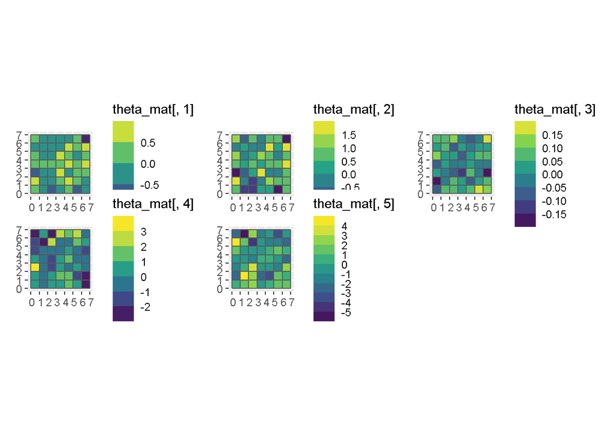

## Model fitting

Compile the models.

```r
comp_n <- stan_model(file = "stan/MPCAR_naive.stan")
comp_e <- stan_model(file = "stan/MPCAR.stan")
```

Collect the two sets of data into their respective lists.

```r
# Naive
data_n <- list(M = M, K = K,
             theta_v = theta, D_W = D_W, C = C, zero = rep(0, M*K))

# Efficient
data_e <- list(M = M, K = K,
             theta_mat = theta_mat, D_W = D_W,
             rho_set = -1)
data_e <- c(data_e, C_for_stan)
```

Fit the two models, keeping track of their running time.

```r
# Naive
  m_s <- Sys.time()
  fit_n <- sampling(object = comp_n,
                  data = data_n,
                  # don't include Omega_A or Omega_S in the output
                  pars = c("Omega_A", "Omega_S"),
                  include = FALSE,
                  chains = 2, iter = 2000, warmup = 1000,
                  cores = 2) #, refresh = 0)
  (rtmins_n <- as.numeric(Sys.time() - m_s, units = "mins"))
```

```
## [1] 4.306084
```

```r
  # Summarize
    # get draws
    its_n <- rstan::extract(fit_n)
    # get summary
    summ_n <- summary(fit_n)$summary %>%
      as.data.frame() %>%
      mutate(n_eff_per_min = n_eff/rtmins_n) %>%
      rownames_to_column("parameter")

# Efficient
m_s <- Sys.time()
fit_e <- sampling(object = comp_e,
                  data = data_e,
                  chains = 2, iter = 2000, warmup = 1000,
                  cores = 2) #, refresh = 0)
(rtmins_e <- as.numeric(Sys.time() - m_s, units = "mins"))
```

```
## [1] 0.2416613
```

```r
  # Summarise
    # get draws
    its_e <- rstan::extract(fit_e)
    # get summary
    summ_e <- summary(fit_e)$summary %>%
      as.data.frame() %>%
      mutate(n_eff_per_min = n_eff/rtmins_e) %>%
      rownames_to_column("parameter")

# takes 20 mins for M=1000, K = 3 - without dot product
# under 2 minute for M=1000, K = 3 - with dot product
# under 4 minute for M=2000, K = 3 - with dot product
# 7 mins to do M=2000, k = 5
```

Given we generated these data, we can assess how well our model estimates the known parameters. We’ll start with the spatial autocorrelation parameter, $\rho$.

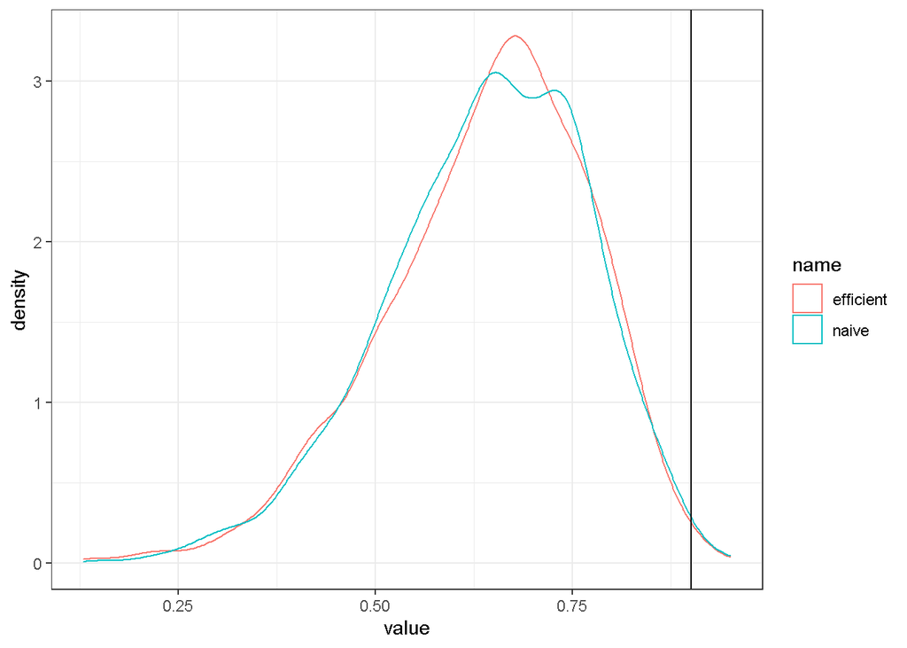

```
##   parameter efficient    naive
## 1       rho  9479.741 637.4678
```

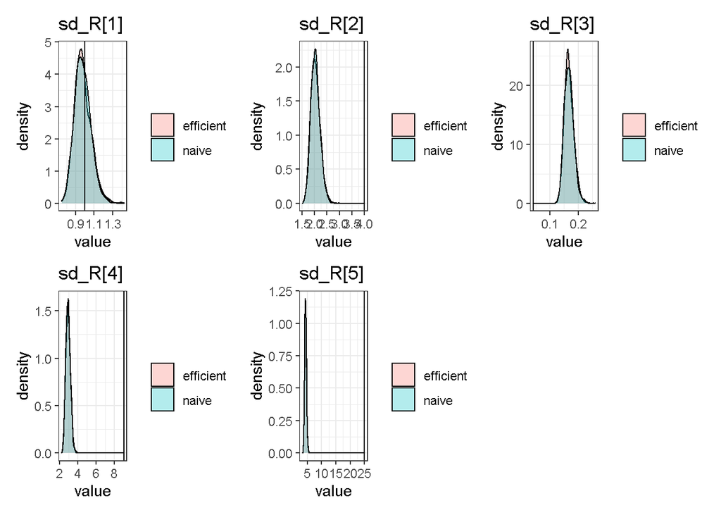

```
##   parameter efficient    naive
## 1   sd_R[1]  6128.017 373.8641
## 2   sd_R[2]  6090.124 341.1047
## 3   sd_R[3]  8204.542 594.3957
## 4   sd_R[4]  8669.657 511.1241
## 5   sd_R[5] 10336.393 592.6173
```

Finally, we’ll investigate the posterior densities of the parameters in the first row of the correlation matrix.

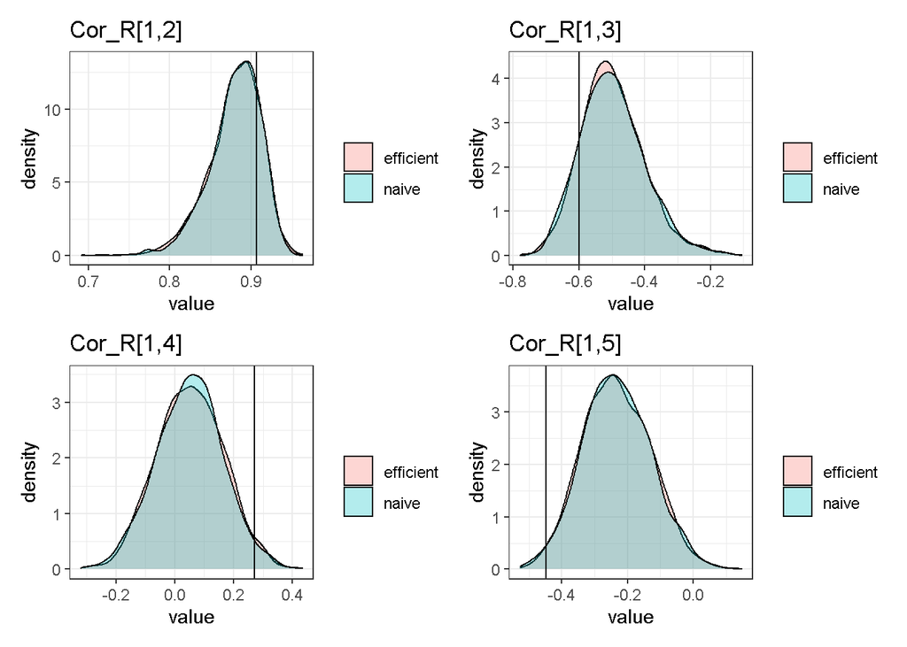

```r
# plot the density
ll <- list()
for(i in 2:5){
  ll[[i]] <- data.frame(efficient = its_e$Cor_R[,1,i],
           naive = its_n$Cor_R[,1,i]) %>%
  pivot_longer(everything()) %>%
  ggplot(aes(x = value, fill = name))+theme_bw()+
  geom_density(alpha = 0.3)+
  geom_vline(xintercept = Cor_R[1,i])+
  labs(title = paste0("Cor_R[1,", i, "]"),
       fill = "")
}
ll[[2]]+ll[[3]]+ll[[4]]+ll[[5]]
```

```r
# compare the sampling efficiency
cbind(summ_e %>%
        filter(str_detect(parameter, "Cor_R\\[1,")) %>%
        dplyr::select(parameter, n_eff_per_min) %>%
        rename(efficient = n_eff_per_min),
      summ_n %>%
        filter(str_detect(parameter, "Cor_R\\[1,")) %>%
        dplyr::select(n_eff_per_min) %>%
        rename(naive = n_eff_per_min))
```

```
##    parameter efficient    naive
## 1 Cor_R[1,1]       NaN      NaN
## 2 Cor_R[1,2]  7299.853 401.3886
## 3 Cor_R[1,3]  8457.664 511.8129
## 4 Cor_R[1,4]  8852.324 464.9613
## 5 Cor_R[1,5] 10034.339 610.5152
```

## Stress test

The example above was on a relatively small dataset as we wanted to fit the naive approach. In this section, we’ll generate a wide range of much larger datasets in order to assess the scalability of our efficient implementation. In addition to the size of the data, we consider a range `c(0,0.2,0.5,0.8,0.98)` for `rho`.

Fitting our efficient implementation to all combinations of `M` and `rho`, we can visualize the accuracy and sampling efficiency. To enable a fair comparison, we’ll compare the sampling efficiency for `rho`.

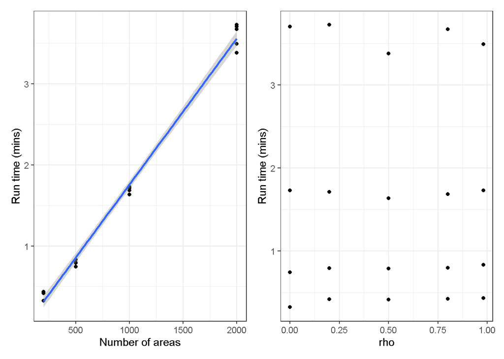

```r
grid <- readRDS(paste0("../data/completed_grid.rds"))

# run time
(grid %>%
  ggplot(aes(y = rtmins, x = M))+
  theme_bw()+
  geom_point()+
  geom_smooth(method = "lm")+
  labs(y = "Run time (mins)",
       x = "Number of areas"))+
(grid %>%
  ggplot(aes(y = rtmins, x = rho))+
  theme_bw()+
  geom_point()+
  labs(y = "Run time (mins)",
       x = "rho"))
```

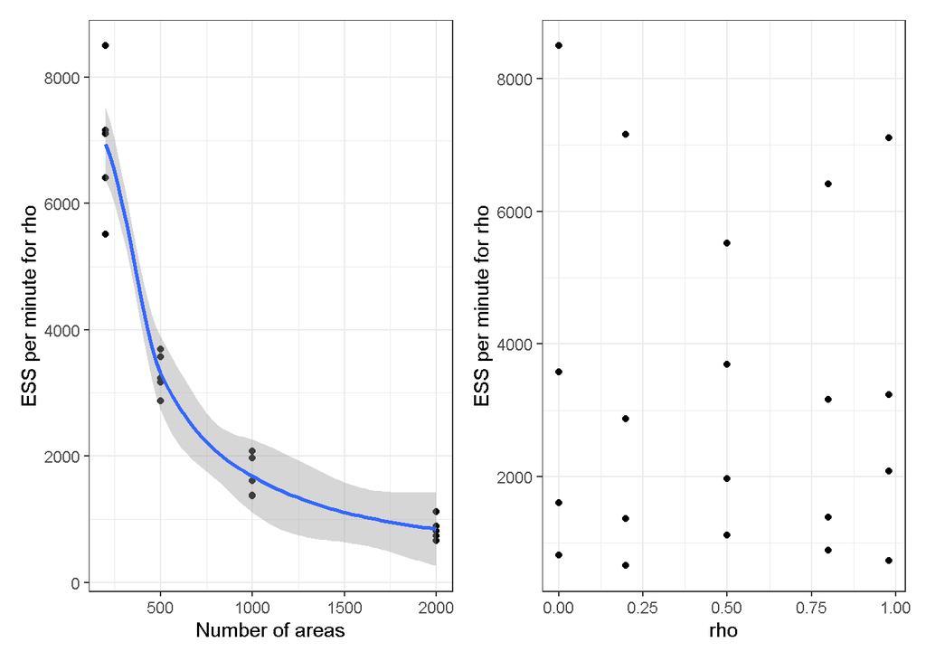

```r
# efficiency
(grid %>%
  ggplot(aes(y = rho_eff, x = M))+
  theme_bw()+
  geom_point()+
  geom_smooth()+
  labs(y = "ESS per minute for rho",
       x = "Number of areas"))+
(grid %>%
  ggplot(aes(y = rho_eff, x = rho))+
  theme_bw()+
  geom_point()+
  labs(y = "ESS per minute for rho",
       x = "rho"))
```

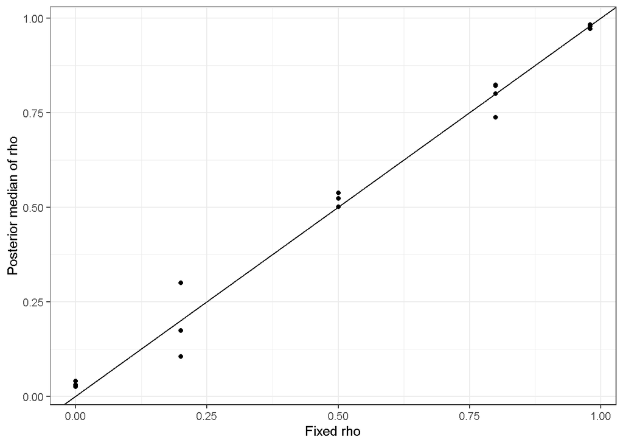

```r
# posterior median
grid %>%
  ggplot(aes(y = rho_median, x = rho))+
  theme_bw()+
  geom_point()+
  geom_abline()+
  labs(y = "Posterior median of rho",
       x = "Fixed rho")
```

# References

1.

Gelfand, A.E., Vounatsou, P.: Proper multivariate conditional autoregressive models for spatial data analysis. Biostatistics. 4, 11–15 (2003)